# Homework 3: Potential Outcomes and Randomized Controlled Trials

STA 235H

Due on Sep. 30th, 11:59pm

# Note

- This document will serve as your Answer Key for Homework 3. Please check the rubric to understand how the assignment is graded.
- All automatically-graded questions will receive full credit if correct or 0 points if they are not correct. The only exception is with multiple answers were points are allocated proportionally.
- Inconsistencies between code and answers will be discounted (i.e. if an answer is correct, but the code used to get to that answer is not, that question will be discounted).
- R scripts and PDF files will also be checked for completeness. If they are not complete (i.e. do not contain the code/output requested), a discount will apply.
- After you receive your graded assignment, you will have one week to submit re-grading requests. Please compare your graded submission with this answer key and fill out the re-grading form with your specific request.

# Task 1 - Putting the DATa into DATing (60 points)

You are interested in knowing what qualities or characteristics people value in a partner, at least when they first meet. In order to do this, you stumble into [this paper](https://academic.oup.com/qje/article/121/2/673/1884033?login=true) by Fisman, Iyengar, Kamenika, & Simonsons (2006), were they ran a study between 2002 and 2004 in speed dating events.

In the study, participants met potential matches for a four-minute date at the event, and after their date, they had to choose whether to accept or reject that partner. If both individuals matched, then they would receive each other’s contact information the following day. We have the data for this study here:

```r
dating <- read.csv("https://raw.githubusercontent.com/maibennett/sta235/main/exampleSite/content/Assignments/Homework/HW3/data/SpeedDatingData.csv")

dating <- dating %>% mutate(income = as.numeric(gsub(",","",income)),
                            race = factor(race, labels = c("Black/AA", "White", "Latino", "AAPI","Other")),
                            race_o = factor(race_o, labels = c("Black/AA", "White", "Latino", "AAPI","Other"))) %>%
  rename(female = gender)
```

The structure of the data consists of one individual-partner per row (you can think of it as each observation is one date). Each observation has characteristics for the individual and its partner (with a suffix “_o”). Some variables from this dataset that we might be interesting:

- `age` and `age_o`: Age of the individual and the partner in years, respectively.
- `income`: Median household income based on zipcode.
- `race` and `race_o`: Race for the individual and the partner, respectively (1: Black/African American, 2: European/Caucasian-American, 3: Latino/Hispanic American, 4: Asian/Pacific Islander/Asian-American, 5: Native American, 6: Other)
- `dec`: Decision of the individual to reject (0) or accept (1) the partner.
- `dec_o`: Decision of the partner to reject (0) or accept (1) the individual.

Additionally, the study collected information about the date’s perception: “You opinion about your date, in a scale of 1 (Awful) to 10 (Great)”:

- `attr`: Attractive
- `sinc`: Sincere
- `intel`: Intelligence
- `fun`: Fun
- `amb`: Ambicious
- `shar`: Shared Interests/Hobbies

## Data inspection

In this first part, we will be looking at our data. Who matched and who didn’t?

**1) Drop all observations with missing income, and then create a new variable called `match` which takes the value of 1 if both people accepted and 0 in any other case. How many observation do we have that matched and how many didn’t match?** (2 points)

Answer:

```r
dating <- dating %>% filter(!is.na(income)) %>% mutate(match = ifelse(dec==1 & dec_o==1, 1, 0))

dating %>% select(match) %>% table()
```

```
## .
##    0    1
## 3543  736
```

In this case, we have 736 observations that matched, and 3543 observations that didn’t match

**2) Let’s compare the characteristics of individuals who matched compared with individuals that didn’t match.**

**2a) Create a histogram (in the same plot) of `income` for individuals that matched and those that did not** (5 points)

Answer:

[figure not shown]

5 points: 2 histograms on the same plot with different colors, correct labels and appropriate bins.

3 points: Missing labels.

2 points: Two separate histograms with correct labels.

0 points: Any other case.

**2b) Run a simple regression of `income` on `match`. What is the average difference in income for someone that matched and for someone that didn’t match?** (2 points)

Answer:

```r
lm_inc <- lm(income ~ match, data = dating)

summary(lm_inc)
```

```
##
## Call:
## lm(formula = income ~ match, data = dating)
##
## Residuals:
##    Min     1Q Median     3Q    Max
## -37281 -13248  -1693   9192  64351
##
## Coefficients:
##             Estimate Std. Error t value Pr(>|t|)
## (Intercept)  44679.9      289.0 154.595   <2e-16 ***
## match         1207.8      696.9   1.733   0.0831 .
## ---
## Signif. codes:  0 '***' 0.001 '**' 0.01 '*' 0.05 '.' 0.1 ' ' 1
##
## Residual standard error: 17200 on 4277 degrees of freedom
## Multiple R-squared:  0.0007019,  Adjusted R-squared:  0.0004682
## F-statistic: 3.004 on 1 and 4277 DF,  p-value: 0.08313
```

```r
options(scipen=999)
```

The average difference in zipcode income and for a person that did match and a person that didn’t is $1208.

**2c) Is that difference statistically significant at 5% level and at 10% level?** (2 points)

Answer:

This difference is not statistically significant at 5% level but it is at the 10% level.

**3) Let’s compare difference between men and women! Run two different regressions using `dec` as your outcome. In terms of covariates, we will add (1) attractiveness (`attr`), female, and its interaction, and (2) fun (`fun`), female, and the interaction**

**3a) Show your code for both regressions** (4 points)

Answer:

```r
options(scipen=0)
library(estimatr)

lm_attr <- lm_robust(dec ~ attr*female, data = dating)

summary(lm_attr)
```

```
##
## Call:
## lm_robust(formula = dec ~ attr * female, data = dating)
##
## Standard error type:  HC2
##
## Coefficients:
##             Estimate Std. Error t value   Pr(>|t|) CI Lower CI Upper   DF
## (Intercept) -0.31170    0.02056 -15.163  1.355e-50 -0.35200 -0.27140 4171
## attr         0.11326    0.00365  31.029 2.209e-190  0.10611  0.12042 4171
## female      -0.15293    0.03702  -4.131  3.682e-05 -0.22550 -0.08035 4171
## attr:female  0.02795    0.00592   4.722  2.410e-06  0.01635  0.03956 4171
##
## Multiple R-squared:  0.2497 ,    Adjusted R-squared:  0.2491
## F-statistic: 667.1 on 3 and 4171 DF,  p-value: < 2.2e-16
```

```r
lm_fun <- lm_robust(dec ~ fun*female, data = dating)

summary(lm_fun)
```

```
##
## Call:
## lm_robust(formula = dec ~ fun * female, data = dating)
##
## Standard error type:  HC2
##
## Coefficients:
##               Estimate Std. Error   t value   Pr(>|t|)   CI Lower CI Upper   DF
## (Intercept) -2.948e-01   0.020252 -14.55851  7.606e-47 -0.3345517 -0.25514 4072
## fun          1.044e-01   0.003451  30.23557 2.378e-181  0.0975855  0.11112 4072
## female       7.748e-02   0.039821   1.94575  5.175e-02 -0.0005892  0.15555 4072
## fun:female  -6.954e-05   0.006335  -0.01098  9.912e-01 -0.0124896  0.01235 4072
##
## Multiple R-squared:  0.1875 ,    Adjusted R-squared:  0.1869
## F-statistic:   476 on 3 and 4072 DF,  p-value: < 2.2e-16
```

4 points: Uses lm_robust and includes the interaction (with no redundant terms)

3 points: Uses lm_robust but includes redundant terms

1 point: Doesn’t use lm_robust(), but formula is correct.

0 point: Any other case

**3b) Is the association between attractiveness and the decision of accept a partner statistically different between males and females? What about for the fun rating?** (2 points)

Answer:

The difference in association for attractiveness is statistically significant, but not for fun.

**3c) Thinking of question 1.3b), how do we know that the difference in associations is statistically significant?** (3 points)

Answer:

We have to look at the statistical significance (p-value) of the interaction term.

- 3 points: Mentions the p-value (or t-stat) of the interaction term
- 1 point: Mentions p-values, but is not specific about which one.
- O point: Any other case.

## Trying to get causal

**We are trying to understand which characteristics matter (and how much) for someone to accept another person as a partner.**

**4) Run a regression with `dec` as the outcome, and use `attr`, `intel`, `fun`. Interpret the coefficient for `attr`.** (3 points)

Answer:

```r
lm_attributes <- lm_robust(dec ~ attr + intel + fun, data = dating)

summary(lm_attributes)
```

```
##
## Call:
## lm_robust(formula = dec ~ attr + intel + fun, data = dating)
##
## Standard error type:  HC2
##
## Coefficients:
##               Estimate Std. Error    t value   Pr(>|t|)  CI Lower  CI Upper
## (Intercept) -5.203e-01   0.029058 -1.791e+01  4.587e-69 -0.577301 -0.463363
## attr         9.480e-02   0.003968  2.389e+01 4.153e-118  0.087018  0.102576
## intel       -2.582e-07   0.004414 -5.849e-05  1.000e+00 -0.008654  0.008654
## fun          5.277e-02   0.003984  1.325e+01  3.119e-39  0.044957  0.060577
##               DF
## (Intercept) 4038
## attr        4038
## intel       4038
## fun         4038
##
## Multiple R-squared:  0.2776 ,    Adjusted R-squared:  0.2771
## F-statistic: 784.1 on 3 and 4038 DF,  p-value: < 2.2e-16
```

For a one-unit increase in attractiveness scale, the probability of accepting a partner increases by 9 percentage points, on average, holding intelligence and fun rating constant.

3 points: Uses lm_robust and the correct words for interpretation (e.g. one-unit increase, change in percentage points/probability, holds variables constant)

1 point: Doesn’t use lm_robust() OR there are some issues with the interpretation (e.g. wording not correct/coefficient not correct)

0 points: Any other case.

**5) We want to analyze the relationship between attractiveness and intelligence. For this, we will create a new dataset. `dating_grouped`, that groups observations by attractiveness and intelligence (e.g. `group_by(attr, intel)`. In this new dataset, create a variable `n` that captures the number of observations in each level of intelligence and attractiveness. For example, if there are three individuals with a rating of 10 in intelligence and a rating of 9 in attractiveness, then, for that row, we should see `attr`=9, `intel`=10, and `n`=3.** *(Hint: You might find the function `n()` useful)*

**Create a scatter plot between intelligence and attractiveness, changing the size of the markers proportionally with the number of observations `n` (you will need to use `size` as an aesthetic!). How does the relationship look like? Is there any data you see it’s missing from this plot?** *Limit both your axis to 0-10* (7 points)

Answer:

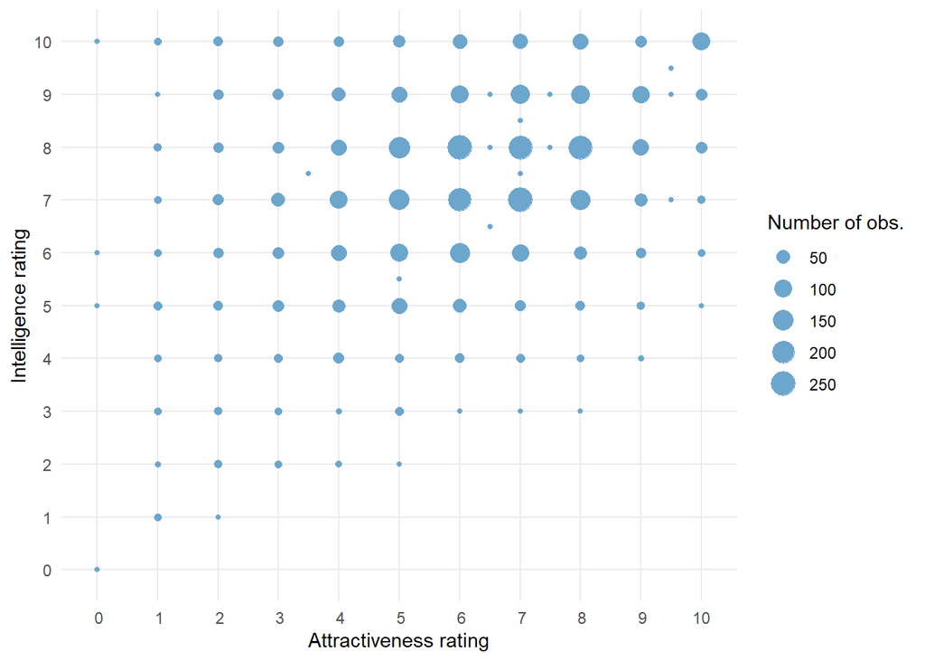

```r
dating_grouped <- dating %>% group_by(attr,intel) %>% summarize(n = n())

ggplot(data = dating_grouped, aes(x = attr, y = intel, size = n)) +
  geom_point(color = "skyblue3") +
  theme_minimal() +
  scale_size("Number of obs.") +
  scale_x_discrete(name ="Attractiveness rating",
                    limits=0:10) +
  scale_y_discrete(name ="Intelligence rating",
                    limits=0:10)
```

- 7 points: Creates dataset correctly and correct a scatter plot, with markers proportional to size and appropriate labels.
- 6 points: Everything is right, but labels are missing.
- 5 points: Data is correct, and scatter plot is overall correct, but doesn’t create markers proportional to size
- 4 points: Scatter plot is overall correct, but the data is not correctly created.
- 1 point: Tries something, but overall is not correct.
- 0 points: Any other case.

**6) Create a binary variable, `attr_bin`, if someone has a level of attractiveness 8 or higher, and 0 if its below 8 (make sure you don’t include missing values in this! If a value is NA in attractiveness, it should be NA in `attr_bin` as well). Create this variable in your previous `dating` dataframe. Regress `match` on your new variable**

**6a) Show your code for creating the variable and running this regression:** (5 points)

Answer:

```r
dating <- dating %>% mutate(attr_bin = ifelse(attr>=8, 1,
                                              ifelse(!is.na(attr), 0, NA)))

lm_attractiveness <- lm_robust(match ~ attr_bin, data = dating)

summary(lm_attractiveness)
```

```
##
## Call:
## lm_robust(formula = match ~ attr_bin, data = dating)
##
## Standard error type:  HC2
##
## Coefficients:
##             Estimate Std. Error t value  Pr(>|t|) CI Lower CI Upper   DF
## (Intercept)   0.1241   0.005944   20.88 3.597e-92   0.1125   0.1358 4173
## attr_bin      0.1968   0.015302   12.86 3.855e-37   0.1668   0.2268 4173
##
## Multiple R-squared:  0.05176 ,   Adjusted R-squared:  0.05153
## F-statistic: 165.4 on 1 and 4173 DF,  p-value: < 2.2e-16
```

- 5 points: Creates the right variable (attr_bin) (no discount for missing values, but doesn’t drop missing obs), uses robust standard errors, and runs the correct regression.
- 4 points: Everything is correct, but drops missing values.
- 3 points: Everything is correct, but uses lm() instead of lm_robust()
- 2 points: Drops missing values AND uses lm()
- 0 points: Any other case.

**6b) What is the estimate?** (2 points)

A person that has a rating of attractiveness of 8 or higher has an average increase in the probability of matching of 19.7 percentage points, compared to someone that has a rating of attractiveness lower than 8.

**6c) Can we say that this is a causal effect? Why or why not? Create a balance table comparing characteristics of both groups (`attr_bin`=1 and =0) to support your answer and give an example. Use sincere, intelligence, fun, ambition, and shared interest.** (4 points)

Answer: No, we can’t say this is a causal effect. Clearly having a high attractiveness rating is associated with other characteristics (e.g. intelligence), and those may influence someone’s “treatment” status. At the same time, those other characteristics also influence your probability of getting a match.

```r
library(modelsummary)
dating_bal <- dating %>% select(attr_bin, intel, sinc, amb, fun, shar)

datasummary_balance(~ attr_bin, data = dating_bal, title = "Balance table - Dating Study",
                    fmt=2,
                    dinm_statistic = "p.value")
```

Balance table - Dating Study

|  | 0 Mean | 0 Std. Dev. | 1 Mean | 1 Std. Dev. | Diff. in Means | p |
| --- | --- | --- | --- | --- | --- | --- |
| intel | 7.27 | 1.56 | 8.23 | 1.29 | 0.95 | 0.00 |
| sinc | 7.04 | 1.76 | 8.11 | 1.45 | 1.07 | 0.00 |
| amb | 6.63 | 1.81 | 7.67 | 1.58 | 1.04 | 0.00 |
| fun | 5.95 | 1.91 | 7.68 | 1.60 | 1.73 | 0.00 |
| shar | 4.99 | 2.03 | 6.51 | 2.03 | 1.52 | 0.00 |

- 4 points: Argues it’s not a causal effect and gives an example on unbalanced confounder.
- 2 points: Argues it’s not causal but doesn’t give an appropriate example from the table.
- 0 points: Any other case.

## Let’s run an experiment

You feel that your previous data was good, but not enough, so you decide to partner with a dating app to conduct an experiment: In the same style as Bertrand and coauthors’ CV experiment, you decide to create fake profiles and see who gets more “hits” (e.g. swipe right). This experiment created 2,000 fake profiles and was tested with 15 people each, randomly allocated. Each profile was allocated to testers from the opposite sex (e.g. if the profile depicted a male, it was tested by females).

Data for your experiment can be found here:

```r
dating_exp <- read.csv("https://raw.githubusercontent.com/maibennett/sta235/main/exampleSite/content/Assignments/Homework/HW3/data/dating_exp.csv")
```

And it has the following variables:

- `id`: ID of the participant
- `male`: Whether the profile is of a male (1) or female (0)
- `funny`: How funny the profile is considered (in a scale of 1-5)
- `hp_job`: The profile contains a high-paying job.
- `retouched_pic`: The profile contains only photos with strong filters.
- `group_pic`: The first photo in the profile is a group picture.
- `complete_profile`: The profile has complete information.
- `city`: City the profile is being tested (NYC, SF, or LA).
- `attractive`: Attractiveness of the photos in the profile (in a scale of 1-10)
- `swipe_right`: Whether a tester swiped right (liked) on the profile (out of 15)
- `n_swipe_right`: Number of testers that swiped right (liked) on the profile (out of 15)

**7) Define a treatment variable, `treat`, which takes the value of 1 if the profile has a rating of attractiveness 8 or higher, and 0 in another case. Check for balance using all the baseline covariates in your data (i.e. don’t include outcomes or variables related to the treatment on your balance table)** *Note: You will need to transform `city` into dummy variables for each city*

**7a) Show your code** (5 points)

Answer:

```r
dating_exp <- dating_exp %>% mutate(treat = ifelse(attractive>=8, 1, 0))

dating_exp <- dating_exp %>% mutate(nyc = ifelse(city == "NYC", 1, 0),
                                    sf = ifelse(city == "SF", 1, 0),
                                    la = ifelse(city =="LA", 1, 0))

dating_exp_bal <- dating_exp %>% select(treat, male, funny, hp_job, retouched_pic,
                                        group_pic, complete_profile, nyc, sf, la)

datasummary_balance(~ treat, data = dating_exp_bal,
                    title = "Balance table - Dating RCT", fmt=3,
                    dinm_statistic = "p.value")
```

Balance table - Dating RCT

|  | 0 Mean | 0 Std. Dev. | 1 Mean | 1 Std. Dev. | Diff. in Means | p |
| --- | --- | --- | --- | --- | --- | --- |
| male | 0.529 | 0.499 | 0.540 | 0.499 | 0.011 | 0.649 |
| funny | 2.979 | 1.420 | 2.926 | 1.404 | -0.053 | 0.433 |
| hp_job | 0.478 | 0.500 | 0.523 | 0.500 | 0.045 | 0.060 |
| retouched_pic | 0.491 | 0.500 | 0.460 | 0.499 | -0.031 | 0.200 |
| group_pic | 0.506 | 0.500 | 0.491 | 0.500 | -0.014 | 0.556 |
| complete_profile | 0.493 | 0.500 | 0.468 | 0.499 | -0.025 | 0.295 |
| nyc | 0.339 | 0.473 | 0.302 | 0.459 | -0.037 | 0.099 |
| sf | 0.325 | 0.469 | 0.351 | 0.478 | 0.025 | 0.271 |
| la | 0.336 | 0.472 | 0.347 | 0.477 | 0.012 | 0.610 |

- 5 points: Creates the right variables, the right balance data set and the balance table.
- 4 points: Everything is right, but includes outcomes in the balance table.
- 3 points: Doesn’t create binary variables for the cities/ Doesn’t include them in the table.
- 2 points: Doesn’t create binary variables for the cities AND includes outcomes in the table.
- 0 points: Any other case.

**7b) Looking at your balance table, select all statements that are TRUE** (2 points)

Answer:

- “The difference between high-paying hobs mentioned in the profiles is statistically significant at a 10% level”
- “Overall, both groups look balanced”

**8) Now you want to assess the magnitude of the effect of your `treat` variable on whether the profiles get a right swipe or not. Right the appropriate regression and interpret the relevant coefficient using causal language.** *Hint: Think about the first regression you should always run when analyzing an RCT.*

**8a) Show your line of code here:** (1 point)

Answer:

```r
summary(lm_robust(swipe_right ~ treat, data = dating_exp))
```

```
##
## Call:
## lm_robust(formula = swipe_right ~ treat, data = dating_exp)
##
## Standard error type:  HC2
##
## Coefficients:
##             Estimate Std. Error t value  Pr(>|t|) CI Lower CI Upper   DF
## (Intercept)   0.1697    0.01018   16.67 1.524e-58   0.1498   0.1897 1998
## treat         0.8052    0.01191   67.60 0.000e+00   0.7819   0.8286 1998
##
## Multiple R-squared:  0.5762 ,    Adjusted R-squared:  0.576
## F-statistic:  4570 on 1 and 1998 DF,  p-value: < 2.2e-16
```

1 point: Correct regression (no covariates, lm_robust())

0 point: Any other case.

**8b) Interpret the coefficient using causal language** (4 points)

Answer:

Having a profile with a rating of 8/10 in attractiveness or higher increases the probability of a right swipe by 80.5 percentage points, on average, compared to a profile with a rating of attractiveness less than 8/10.

- 4 points: Point estimate is correct, identifies both treatment and control status (contrast), uses “on average”, doesn’t use “association”, uses “percentage point” or “change in probability”.
- 3 points: Overall correct, but doesn’t identify the control/ doesn’t identify what the treatment is/ doesn’t use “on average”/ uses “association”/ uses “holding other variables constant”.
- 2 points: Problems in two of the previous issues OR uses wrong units OR point estimate is wrong.
- 0 points: Any other case.

**8c) Include now baseline covariates to your model. Does your estimate change?** (1 point)

Answer:

```r
summary(lm_robust(swipe_right ~ treat + funny + male + hp_job + retouched_pic +
                    group_pic + complete_profile + nyc + sf, data = dating_exp))
```

```
##
## Call:
## lm_robust(formula = swipe_right ~ treat + funny + male + hp_job +
##     retouched_pic + group_pic + complete_profile + nyc + sf,
##     data = dating_exp)
##
## Standard error type:  HC2
##
## Coefficients:
##                   Estimate Std. Error t value  Pr(>|t|)  CI Lower  CI Upper
## (Intercept)       0.040930    0.02432  1.6829 9.255e-02 -0.006767  0.088627
## treat             0.803404    0.01191 67.4717 0.000e+00  0.780052  0.826756
## funny             0.018214    0.00510  3.5717 3.631e-04  0.008213  0.028215
## male              0.121845    0.01391  8.7584 4.148e-18  0.094562  0.149128
## hp_job            0.032946    0.01412  2.3325 1.978e-02  0.005245  0.060647
## retouched_pic     0.011793    0.01416  0.8329 4.050e-01 -0.015973  0.039559
## group_pic         0.004587    0.01406  0.3262 7.443e-01 -0.022986  0.032160
## complete_profile  0.014676    0.01409  1.0414 2.978e-01 -0.012962  0.042313
## nyc              -0.038142    0.01693 -2.2525 2.440e-02 -0.071350 -0.004934
## sf               -0.024838    0.01787 -1.3899 1.647e-01 -0.059885  0.010209
##                    DF
## (Intercept)      1990
## treat            1990
## funny            1990
## male             1990
## hp_job           1990
## retouched_pic    1990
## group_pic        1990
## complete_profile 1990
## nyc              1990
## sf               1990
##
## Multiple R-squared:  0.5962 ,    Adjusted R-squared:  0.5944
## F-statistic: 741.5 on 9 and 1990 DF,  p-value: < 2.2e-16
```

No

**9) We now want to see whether males and females have different considerations for attractiveness. Interact your model in 2.7) with `male` (remember that male profiles were rated by females).**

**9a) Show your regression code here:** (1 point)

Answer:

```r
lm_swipe <- lm_robust(swipe_right ~ treat*male, data = dating_exp)

summary(lm_swipe)
```

```
##
## Call:
## lm_robust(formula = swipe_right ~ treat * male, data = dating_exp)
##
## Standard error type:  HC2
##
## Coefficients:
##             Estimate Std. Error t value  Pr(>|t|) CI Lower CI Upper   DF
## (Intercept)  0.08424    0.01098   7.673 2.609e-14  0.06271  0.10578 1996
## treat        0.87154    0.01627  53.560 0.000e+00  0.83963  0.90345 1996
## male         0.16159    0.01945   8.307 1.790e-16  0.12344  0.19974 1996
## treat:male  -0.12607    0.02340  -5.387 8.017e-08 -0.17196 -0.08017 1996
##
## Multiple R-squared:  0.5947 ,    Adjusted R-squared:  0.5941
## F-statistic:  2354 on 3 and 1996 DF,  p-value: < 2.2e-16
```

1 point: Correct regression (lm_robust())

0 point: Any other case.

**9b) What is the treatment effect for males?** (2 points)

Answer:

For males, having a highly-attractive profile increases your probability of being swiped right by 75 percentage points, on average, compared to a less attractive profile.

**9c) What is the treatment effect for females?** (2 points)

Answer:

For females, having a highly-attractive profile increases your probability of being swiped right by 87 percentage points, on average, compared to a less attractive profile.

**9d) “The difference in the treatment effect between males and females is statistically significant** (1 point)

Answer:

The difference is statistically significant at conventional levels.